# Introduction to lm() for linear models

Jessi Cisewski Kehe

Fall 2020

# Simple linear regression model

## Overview

A simple linear model has the following form:

$$y_i = \beta_0 + \beta_1 x_i + \varepsilon_i$$

- $y_i$ is the dependent variable (depends on $x_i$)
- $x_i$ is the independent/explanatory variable
- $\beta_0$ is the unknown y-intercept
- $\beta_1$ is the unknown slope
- $\varepsilon_i$ is the random error

Often we have a dataset with values for the pairs $(x_i, y_i)$ with $i = 1, \ldots, n$ ($n$ is the total number of observations). Using this dataset, we can estimate the unknown parameters $\beta_0$ and $\beta_1$.

There are various assumptions that are often made on this model.

1. The $\varepsilon$ is considered a random variable which has a mean of 0, which we can write as $E(\varepsilon_i) = 0, i = 1, \ldots, n$
2. Errors have a constant variance: $Var(\varepsilon_i) = \sigma^2$, $i = 1, \ldots, n$
3. Errors are uncorrelated

If wanting to do inference on this model, additional assumptions may be made on the distribution of the $\varepsilon_i$’s. For example, it is common to assume that the $\varepsilon_i$ come from a normal distribution with a mean of 0 and a standard deviation of $\sigma$.

This code displays different normal density curves (don’t worry about the code, but focus on the resulting plot).

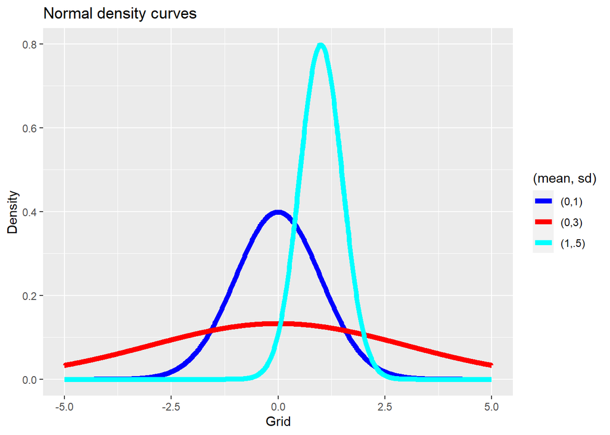

```r
grid <- seq(-5, 5, length.out=1000) # create a grid
y1 <- dnorm(grid, mean=0, sd = 1) # density curve of a normal distribution with mean=0, stand. dev.=1
y2 <- dnorm(grid, mean=0, sd = 3) # density curve of a normal distribution with mean=0, stand. dev.=3
y3 <- dnorm(grid, mean=1, sd = .5) # density curve of a normal distribution with mean=1, stand. dev.=.5

normal <- tibble(grid=grid, y1=y1, y2=y2, y3=y3) # combine data into a tibble
colors <- c("(0,1)" = "blue", "(0,3)" = "red", "(1,.5)" = "cyan") # set color assignments
ggplot(normal, aes(x=grid)) +
  geom_line(aes(y=y1,color="(0,1)"), size=2) +
  geom_line(aes(y=y2,color="(0,3)"), size=2) +
  geom_line(aes(y=y3,color="(1,.5)"), size=2) +
  labs(title = "Normal density curves",
       x = "Grid",
       y = "Density",
       color = "(mean, sd)") +
  scale_color_manual(values = colors)
```

The take-away here is that a normal density curve is unimodal (a single peak), symmetric, and bell-shaped. The peak of the density curve is at the mean $\mu$ and the width is related to the standard deviation $\sigma$.

## Fitting the linear model using the lm() function

### Generate our data

We are going to create a simulated (i.e, fake) dataset and then use the `lm()` function to fit a linear model using our simulated data.

To generate the date, we will specify (i) a sample size using the variable name `n`, (ii) explanatory variable values `x` by drawing `n` random numbers (uniformly) between 0 and 10, (iii) `sigma` is the standard deviation of the error variable, (iv) error variable values `error` by drawing `n` random numbers from a normal distribution centered at 0 with a standard deviation `sigma`, (v) an intercept value `beta0`, (vi) a slope value `beta1`, and finally (vii) the response variable values `y` by defining the linear model plus error as `beta0 + beta1*x + error`. We then bring the `x` and `y` together in a data frame called a *tibble*.

Notice that we are generating data that perfectly satisfy all the assumptions in the model, including the linearity between `x` and `y`. In practice, we would have to check these assumptions to see if a linear model is appropriate.

```r
set.seed(246) # Setting our random seed so the dataset always comes out the same
n <- 50 # set our sample size
x <- runif(n, 0, 10) # explanatory variable
sigma <- 2 # standard deviation of error
error <- rnorm(n, 0, sigma) # error
beta0 <- 2 # intercept
beta1 <- -3 # slope
y <- beta0 + beta1*x + error # generate our response variable y
dset <- tibble(x=x,y=y) # create our data frame for analysis
str(dset)
```

```
## tibble [50 x 2] (S3: tbl_df/tbl/data.frame)
##  $ x: num [1:50] 7.03 2.06 5.99 2.88 3.86 ...
##  $ y: num [1:50] -20 -5.7 -16.07 -7.48 -9.6 ...
```

Let’s plot our data to see what we generated. Notice that the points decrease with increasing values of `x`. This is because our slope, `beta1`, is negative. You can try changing the values for the model and see how that changes the plot. For example, if you change the standard devation for `error` to .1 or 10, what happens?

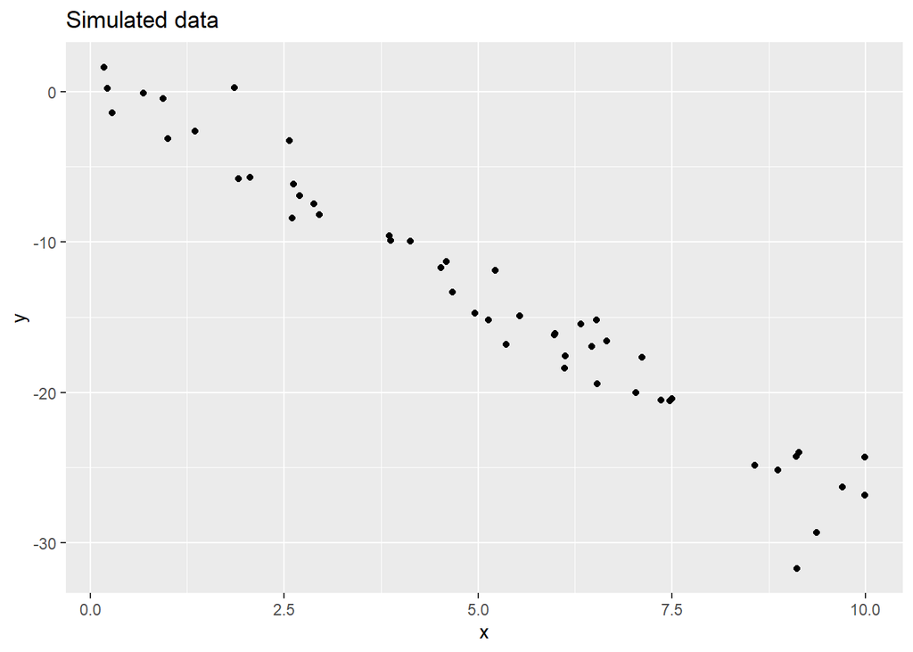

```r
ggplot(dset, aes(x,y)) +
  geom_point() +
  ylab("y") +
  xlab("x") +
  ggtitle("Simulated data")
```

### Fit the linear model

We can use the function `lm()` to fit our linear model. It uses the least-squares method (we won’t discuss the details yet). The form of the input is `lm(response-variable-name ~ explanatory-variable-name, data-frame-name)`.

```r
lm1 <- lm(y~x, dset) # fit the model
coefficients(lm1) # view estimated coefficients for beta0 and beta1
```

```
## (Intercept)           x
##    1.302961   -2.931763
```

```r
fitted(lm1) # gives the fitted values of the model
```

```
##           1           2           3           4           5           6
## -19.3105062  -4.7321097 -16.2627934  -7.1413764 -10.0118448 -17.8327229
##           7           8           9          10          11          12
##  -0.7189712   0.7925934 -13.7538035  -6.3422598 -25.3912624  -2.6472599
##          13          14          15          16          17          18
## -26.1541295   0.6470343 -18.2193453 -17.6430462 -20.6854571  -7.3534127
##          19          20          21          22          23          24
## -17.8542288 -14.9298043 -16.2365022 -16.6391484 -23.8082880   0.4647550
##          25          26          27          28          29          30
## -10.0442684  -6.6257869 -20.2662667 -12.3885145 -12.1720824  -6.3936032
##          31          32          33          34          35          36
## -27.9730589 -24.6993426 -14.4196202 -13.2336857 -27.9661932 -19.5481135
##          37          38          39          40          41          42
##  -4.1434490 -20.6006634 -11.9425646  -4.2894889 -17.2339060 -10.7944123
##          43          44          45          46          47          48
## -25.4124807  -6.2153237 -27.1221123 -25.4787013 -16.6544344 -14.0062236
##          49          50
##  -1.6217075  -1.4478719
```

```r
summary(lm1) # summarizes the model fit; just look at this, but don't worry about understanding the content
```

```
##
## Call:
## lm(formula = y ~ x, data = dset)
##
## Residuals:
##     Min      1Q  Median      3Q     Max
## -6.2691 -0.9572  0.0671  0.8482  4.3846
##
## Coefficients:
##             Estimate Std. Error t value Pr(>|t|)
## (Intercept)  1.30296    0.52084   2.502   0.0158 *
## x           -2.93176    0.08893 -32.966   <2e-16 ***
## ---
## Signif. codes:  0 '***' 0.001 '**' 0.01 '*' 0.05 '.' 0.1 ' ' 1
##
## Residual standard error: 1.795 on 48 degrees of freedom
## Multiple R-squared:  0.9577, Adjusted R-squared:  0.9568
## F-statistic:  1087 on 1 and 48 DF,  p-value: < 2.2e-16
```

The code below adds a column to our data frame with the fitted values of the model.

```r
dset2 <- dset %>%
  mutate(fit = fitted(lm1)) # Add a column to our data frame with the fitted values)
```

Now we can plot our data with the model fit. Notice that the estimate of $\beta_0$ is 1.3 while our true input value was 2; the estimate of $\beta_1$ is -2.9 while our true input value was -3. We’ll discuss our estimate for `sigma` below.

The `geom_smooth(se=FALSE,method="lm")` actually plots the same fit as our model!

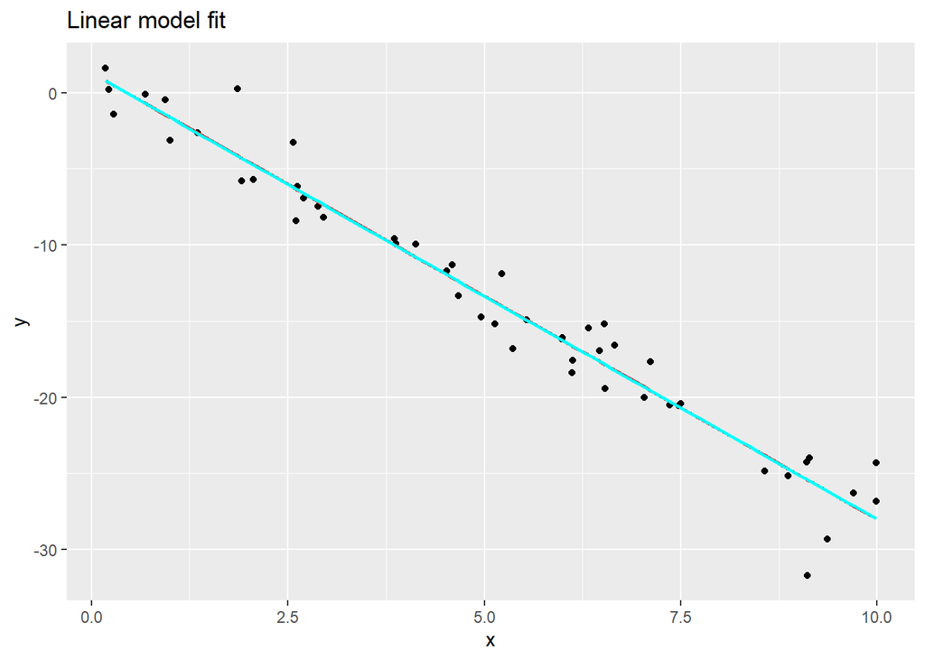

```r
ggplot(dset2, aes(x=x,y=y)) +
  geom_point() +
  geom_line(aes(y=fit),color="red", size = 1) +  # our fit model
  geom_smooth(se=FALSE,method="lm",color="cyan",size=1) +  # this fits the same line as our model!
  ylab("y") +
  xlab("x") +
  ggtitle("Linear model fit")
```

### Residuals

For each model, let $\hat{y}_i$ represent the value *predicted* by the model for the data point $y_i$. That is,
$$\hat{y}_i = \hat{\beta_0} + \hat{\beta_1}x_i, \quad i = 1, \ldots, n$$
where $\hat{\beta_0}$ is our estimated $\beta_0$ and $\hat{\beta_1}$ is our estimated $\beta_0$.

Data scientists are interested in evaluating the performance of their model. One consideration is how far $\hat{y}_i$ is from $y_i$; this distance is called the residual.

The $i$th residual may be defined as
$$r_i = y_i - \hat{y}_i$$
Notice that if $y_i > \hat{y}_i$, then $r_i$ is positive; if $y_i < \hat{y}_i$ then $r_i$ is negative; if $y_i = \hat{y}_i$ then $r_i = 0$.

We can access our estimated residuals using the `residuals()` function by inputting our linear model object name, `lm1`. In the code below, we add a new column to our `dset2` with the residuals.

```r
residuals1 <- residuals(lm1)
dset2 <- dset2 %>%
  mutate(residuals = residuals1) # Add a column to our data frame with the fitted values)
```

The following plot shows out data with the model fit, and then the added vertical bars indicate the residuals.

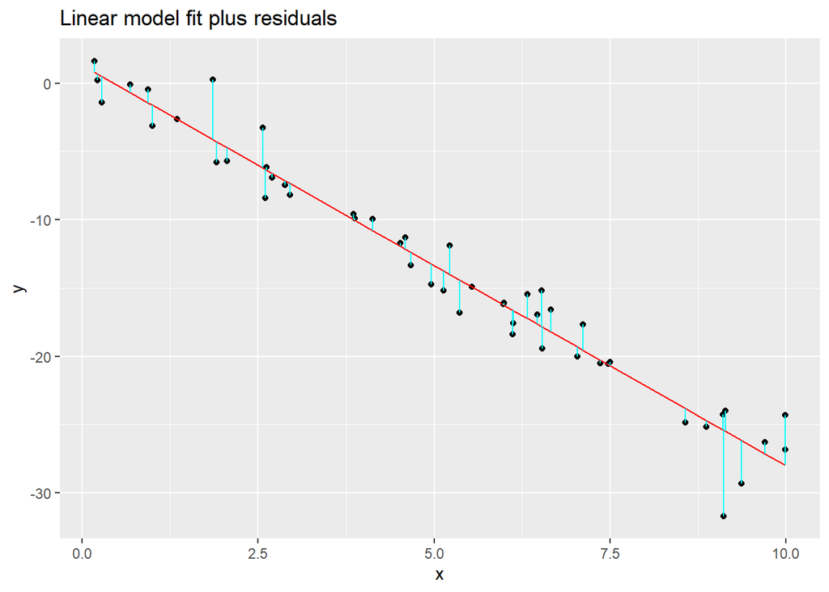

```r
ggplot(dset2, aes(x=x,y=y)) +
  geom_point() +
  geom_line(aes(y=fit),color="red") +
  geom_segment(aes(xend=x, yend=fit), color="cyan") +  # draws segments between (x,y) and (xend,yend)
  ylab("y") +
  xlab("x") +
  ggtitle("Linear model fit plus residuals")
```

- We can summarize the residuals by computing their *standard deviation* $s$. The general form of a sample standard deviation of numbers $x_1,\ldots,x_n$ which have mean $\bar{x} = \frac{1}{n}\sum_{i=1}^nx_i$ is
  $$s = \sqrt{ \frac{\sum_{i=1}^n (x_i - \bar{x})^2}{n-1} }$$
  which is (almost) the square root of the average squared deviation from the mean.

The mean of the estimated residuals (up to numerical error) equal to zero, so we are (almost) calculating the square root of the mean of the squared residuals.

```r
mean(residuals1) # mean of the estimated residuals
```

```
## [1] -1.330099e-17
```

The reason we divide by $n-1$ instead of $n$ has to do with a result from mathematical statistics about the expected value of the square of the sample standard deviation, called the sample variance.

We can use the function `sd()` to calculate the standard deviation of our residuals.

```r
sd_residuals <- sd(residuals1)
sd_residuals
```

```
## [1] 1.7767
```

Hence, the estimate of $\sigma$ is 1.7767004 while our true input value was 2

One thing to do with the residuals is to plot the residual versus the explanatory variable $x$ and look for patterns. Why might this be useful?

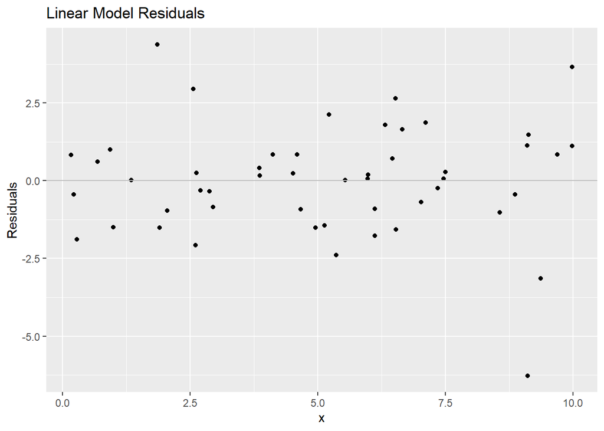

```r
ggplot(dset2, aes(x=x, y=residuals1)) +
  geom_point() +
  geom_hline(yintercept = 0, color="gray") +
  ylab("Residuals") +
  xlab("x") +
  ggtitle("Linear Model Residuals")
```